# Week-13: Diary Entry + Final Submission

Chen Zi Xin

2023-10-19

**Week 9** The theme of my data story is successful dating and breaking down the factors, mainly focusing on personality traits. I currently have a data set from Kaggle on speed dating which covers multiple factors of what people look for in a partner.

**Week 10**

The question that I will answer is: Finding the right one - what makes an ideal partner? This question is important as according to an article by TodayOnline, we are in the ” slowest decade of population growth since 1970”. Based on another article by TodayOnline, the lack of confidence plays a big part as “It’s usually those who are quiet, socially awkward… they don’t know how to make themselves attractive and it slowly snowballs”, as shared by an interviewee. In addition to Zula’s recent article, “Survey Shows 81% Of Singaporeans Prefer To Date Someone Kind, Physical Attributes Not As Important”, it mentions that “81% of the respondents also mentioned that being kind is more important than physical attributes” and this motivates to me further pick out important attributes to help single and lost individuals better understand what could improve their chances of getting matched. As speed dating is becoming increasingly popular, it is crucial to be well-prepared beforehand to match effectively. Not only is it important to know what you can bring to the table but also to know what the opposite party is looking for.

1. Matches (to narrow down to successful cases)
2. Age (see which age range has more succes cases)
3. attr ,sinc ,intel ,fun ,amb ,shar (different attributes)
4. Gender (Visualise Male vs Female data sets)
5. Field (Consider the other factors like what they study, other interests)
6. Age (See which age range is the golden period to look for love)

I think the data set is quite big as there were many stages to the survey and it gets a little overwhelming cleaning the data as there are many filters and I think it would be the hardest part. To make things easier, I made sure to know what I want to get from the data set, like a flow chart so I can filter out the data step by step. I realised that planning out what to do is important also as there are many ways to filter the data, it really depends on how the data needs to be visualised. If I want to compare it, I need numerical data and I have to clean it up and ensure that I convert the data or split it properly. To ovecome this, I started writing down the specific data I want and really spend time planning with the purpose of filtered data in mind.

**Week 11** I think I would make a graph or slider to separate the male and female data. The visualisations will be to compare the different attributes that have proven to be successful as well as the field of study. It breaks the bigger question down to the various factors and the specific data. It allows one to see the ranking of their top attribute. The variables that I will be plotting include age, field of study and more importantly, ranking of attributes. It answers the bigger question. I browsed through the different ggplots available and I think I will heavily utilise it. For interactive, I would use shiny.io and incorp orate it into my webpage. I think that I would only have one interactive as it would not be a main feature but something good to have. I will further explore the features to see what makes the data clear and easy to understand

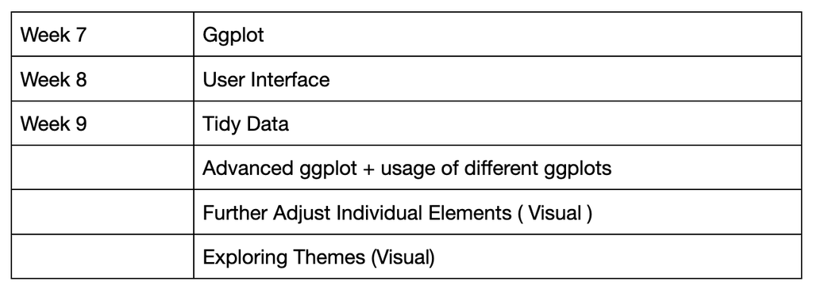

```r
knitr::include_graphics("/Users/chenzixin/Documents/GitHub/My-tutorial/week-11/imgs/table.png")
```

I think one of the bigger challenges I faced was with having too much data and not being able to decide on what to show for the visualisation and that led to me not being able to properly clean and tidy my data. I also felt that I should have more datasets so that I can cross reference and make sure that my hypothesis is truly supported. I think planning is the biggest challenge now and once I am set on what I want to do, I think it will be alright. I think writing all these down and planning on paper will help make this easier, not just the content but also the layout of the webpage. Also, when I am doing up the webpage, I keep having ideas on how to further improve the webpage so it changes the track that I am on. I have to relook at my plan and clean the data again. I think there is nothing wrong with wanting to make changes but to improve, I would need to write down on paper again to keep track of my thought process, at least it is what works well for me. In attempt to finish the webpage as fast as possible, I kept trying to skip steps and just write the code in qmd which wasted alot of time as I was not able to get the data I wanted. Doing it once properly saves so much more time than cutting corners especially when it comes to coding because it takes very long to find the problem with the code.

**Week 12** As I am more than half done with my webpage, I think I can solve quite a few challenges now. Also, instead of trying to solve everything by myself, I choose to seek help from ChatGPT if I am taking too long to solve it. It does get quite frustrating when ChatGPT does not resolve problems with my code but also it boils down to the way I phrase my sentences - which reflects how clear I am on what I want. It progressively got more efficient as I got clearer on what I wanted along the way. I think that I am so used to thinking outside the box, sometimes I miss things that are right in front of me. I started taking short breaks to make sure that I could be productive and not miss out on anything. I think it is important to take breaks because sometimes the direction that I am working is not right, to begin with, but I want to make it work so I try to force my way through but it does not work that way. With the frustration, I was stuck on my code for so long when all I had to do was add a missing bracket or comma. It is quite hard to rush and force things with coding seeing how detailed it is and the patience it requires.

**Final Submission**

The theme of my data story is successful dating and breaking down the factors, mainly focusing on personality traits. This topic has been increasingly discussed, with a negative connotation to the current dating scene. The question that I want to answer is: Finding the right one - what makes an ideal partner? This question is important as according to an article by TodayOnline, we are in the “slowest decade of population growth since 1970”. Based on another article by TodayOnline, the lack of confidence plays a big part as “It’s usually those who are quiet, socially awkward… they don’t know how to make themselves attractive and it slowly snowballs”, as shared by an interviewee. In addition, Zula’s recent article, “Survey Shows 81% Of Singaporeans Prefer To Date Someone Kind, Physical Attributes Not As Important”, mentions that “81% of the respondents also mentioned that being kind is more important than physical attributes” and this motivates to me further pick out important attributes to help single and lost individuals better understand what could improve their chances of getting matched. As speed dating is becoming increasingly popular, it is crucial to be well-prepared beforehand to match effectively. Not only is it important to know what you can bring to the table, but also to know what the opposite party is looking for.

The data sources I have curated help answer the question as they cover many aspects such as age, career, ranking of attributes and more. Initially, I was going to focus on personality traits only, but the data allowed me to explore other factors that would make my webpage more well-rounded. It is coherent as it is true that other factors also play a part when finding a partner. With the high response rate, I can provide more accurate data that better represents the general public. With the data source that I have, I felt that it was sufficient for my webpage as there are different factors and various categories of variables that I could compare within the existing dataset. The insights I obtained from the dataset were surprising to a certain extent. Firstly, I compared the different attributes with the mean score through a boxplot graph. Which helped analyse and filter the ranking of all the attributes. I was worried that the plot would be messy, but upon getting feedback from my peers, they understood how it supported my analysis. When faced with the amount of data, I planned to make things easier to break down and understand by splitting the data into male and female, then eventually realised that gender could be an affecting factor, thus using the general data. Secondly, I analysed how the different genders affect the data, which I found interesting as I did not expect the top three attributes for both genders to be the same. I assumed being attractive would be higher as it is speed dating data, so first impressions heavily depended on looks. I compared the data from both genders and colour-coded it to make it easy to understand. Helping readers see that different genders do have differing priorities. After analysing the personality traits, I explored other factors, starting with age. By using the successful matches, I filtered the data down to see which age had the highest success rate, which was the twenties range. There is a significant drop in the 30 to 40 range but it shows that success is not limited to a specific age range. The last visualisation is for fields of study. From this, we can see which fields are more popular among all the successful matches - business. Perhaps if I used local data instead, the top few choices would be different. I was surprised to find social work as one of the top. Due to the nature of the data, it made it easy for me to compare as there were so many variables per category, I just had to compare within each column to find the best results. I conclude that someone with a business background, preferably in their 20s with qualities including intelligence, sincerity and ambitious would have much higher chances of success in speed dating.

Due to the wide range of data, I tried to keep the visualisations simple so it does not seem messy and can be easily understood. I took quite some time to clean the data, but it was manageable as everything I needed was in the slides. I attempted to reach my data with one efficient line code. Through this, I also understood the importance of proper naming for each dataset as it gets confusing when dealing with so many sets of cleaned data. I also started writing down the specific data I want before coding to cross-check with the data I obtain after cleaning to see if I am on the right track. After cleaning the data, I moved on to draw the layout of the webpage, a simple layout focusing on the placement of everything from text to image and interactive panels. This helped to visualise the flow before I allocated the respective information that helped with the flow of my analysis. I then sketched out the plots I had in mind before attempting to recreate them on the webpage. With the initial sketch and allocated header for each section, I could churn out the content for the introduction paragraph efficiently. When coding the first interactive slider, I wanted to make it stationary as it was scrolling in its bounding box that did not fit the one scroll webpage. Creating the slider was smooth but I had to keep publishing to see how it is reflected on the webpage. Also, through inserting the images, I realised the difference between WWW and SRC files. Creating the attributes plot was painful. I initially wanted to create one for each gender, but I had to combine all the data and clean it up into two sets of data so I went ahead with general data. I think I generally learned how to filter out data that are not as impactful. For the last plot, there were too many fields, the plot was messy thus I cut down to the top 5.

Overall, this project was much more manageable than expected. The codes did not have to be complicated and there were various sources to get help from. It encouraged self learning as well, which is the biggest takeaway. I fostered a greater interest in coding and learnt alot outside of class. I learnt to plan before executing, a skill that will be of use for future projects. I realised that coding is not as hard as expected as there are many ways to resolve errors. It boils down to how passionate and how much I want to learn because there are resources available that could help make significant improvements on my webpage. Though frustrating, the sense of accomplisment is undeniably overwhelming. It encourages me to not give up easily and motivates me to challenge myself. There is so much more to learn and discover. This project excites me to further explore coding and I look forward to improving my coding skills as well as gain more skillsets along the way.

[1200 words]

Webpage: https://c-zixin.github.io/

Montoya, A. (2016, May 9). Speed dating experiment. Kaggle. https://www.kaggle.com/datasets/annavictoria/speed-dating-experiment Tan, J. T. (2023, August 2). Survey shows 81% of Singaporeans prefer to date someone kind, physical attributes not as important. ZULA.sg. https://zula.sg/singaporeans-changing-dating-preferences/ Noshizaman. (2023, July 4). The transformative power of sincerity in relationships. Medium. https://medium.com/@noshizaman4/the-transformative-power-of-sincerity-in-relationships-e4ff5dca4625#:~:text=It%20fosters%20trust%2C%20nurtures%20authenticity,cornerstone%20of%20healthy%2C%20fulfilling%20relationships.  
GeorginaBerbari. (2018, December 12). Proof that being intelligent makes you more attractive. mindbodygreen. https://www.mindbodygreen.com/articles/being-intelligent-makes-more-attractive-study  
Forgeard, A. V. (2023, July 31). Why is ambition attractive: The irresistible power of purpose. Brilliantio. https://brilliantio.com/why-is-ambition-attractive/#:~:text=Ambitious%20people%20are%20attractive%20because,companions%20but%20also%20influential%20leaders.  
Lim, J. (2021, June 16). 2020 census: More singles in all age groups; slowest decade of population growth since 1970. TODAY. https://www.todayonline.com/singapore/2020-census-more-singles-singapore-all-age-groups-rate-population-growth-slowest-1970